# Análise RFM - Recency, Frequency e Monetary Value

A análise RFM é um modelo de **clusterização** de clientes que visa dividi-los em grupos para 3 características:

- **Recência**

Última vez que o cliente fez uma determinada ação (precisa ser definido pelo negócio), geralmente uma compra ou um engajamento específico;

- **Frequência**

Quantidade de ações (compras, engajamentos, etc) realizados pelo cliente em um intevalo de tempo definido.

- **Valor Monetário**

Quantia total gasta ou alguma quantificação de valor recebido do cliente.

### Primeiros passos

A primeira questão importante a se atentar é a definição de como serão divididos estes grupos. Pode ser uma definição personalizada da empresa seguindo alguma diretriz específica do negócio ou seguir algumas regras quantitativa como a divisão 80/20 de Pareto ou a partir dos **percentis**.

Neste estudo será exemplificado o modo a partir dos percentis, onde os clientes são dividios em **grupos de mesmo tamanho** a partir da quantidade de níveis escolhida para cada variável (R, F e M).

### Por exemplo:

Se o negócio definir o R, F e o M em 5 níveis para cada cliente, o processo manual para o R (recency) seria:

- Identificar o cliente que comprou a menos tempo a atribuir a ele a maior nota de Recência (5);
- Identificar o cliente que comprou a mais tempo e atribuir a ele a menor nota de Recência (1);
- Entre estes dois clientes, encontrar o indivíduo que divide a distribuição no meio e atribuir a ele a nota (3);

Note que estamos encontrado **O CLIENTE** que divide a distribuição no meio e não a data do meio do período, ou seja, estamos dividindo os clientes em 2 grupos de mesma quantidade. Tecnicamente, esté cliente é a **mediana** ou o percentil de 50%.

- Entre o cliente nota 1 e o cliente nota 3, encontrar o cliente que divide a distribuição no meio e atribuir a ele nota (2);
- Entre o cliente nota 3 e o cliente nota 5, encontrar o cliente que divide a distribuição no meio e atribuir a ele nota (4);

Perceba que esta divisão cria 5 grupos de mesmo tamanho. Portanto se entrarem 2 clientes no grupo dos que tem nota (3) em Recência, um cliente precisará passar para nota (2) ou (4) a depender dos valores.

**Mas ATENÇÃO!**

Um ponto positivo é que a clusterização acontece de maneira **relativa**, sendo pouco influenciada por outliers e se auto-ajustando de acordo com as tendências gerais. Contudo, ela não fornece insumos para avaliações globais como taxas de retorno, valores gastos, entre outros.

**Como assim?**

Imagine que uma empresa X tenha péssimos indicadores de faturamento, quantidade de vendas e retorno. Ainda assim, a análise dividirá os clientes **igualitáriamente** entre os níveis, havendo o mesmo números de indivíduos no nível 1 e no 5. Ou seja, os clientes do nível 5 podem estar gastado pouco em relação ao esperado pelo negócio, porém **relativamente** eles estão no nível mais alto de (M).

Os níveis RFM são relativos aos demais individuos da amostra.

**Como utilizar a matriz RFM**

Alguns portais sugerem classificar as diferentes porções da matriz em cluster e traçar diretrizes para cada cluster de cliente de acordo com suas necessidades e expectativas.

Um exemplo de matriz é a seguinte, o crédito do design é do portal [Vida de Produto](https://vidadeproduto.com.br/analise-rfm/).

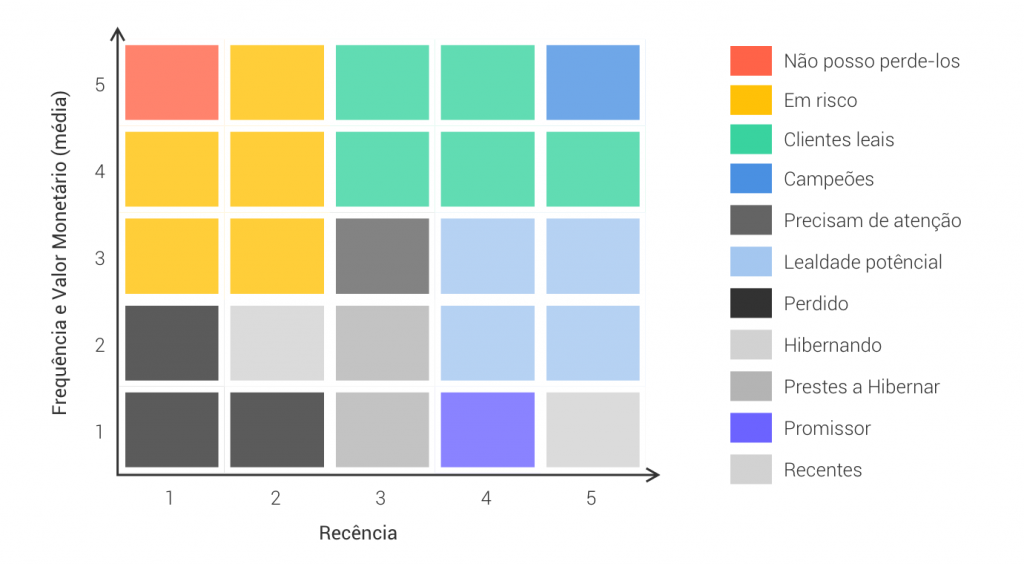

## Mão na massa: hora do código!

Para este exemplo será utilizado um conjunto de dados do [repositório da UCI](https://archive.ics.uci.edu/).

**Se você já viu nosso artigo sobre Análise Coorte, pode pular a etapa de leitura e tratamento dos dados, pois são as mesmas etapas já realizadas no artigo da Análise Coorte.**

Os dados estão em uma planilha do excel (.xlsx) e representam vendas de uma loja on-line no Reino Unido. As colunas presentes no dataset são:

- `Número do pedido`;
- Código do produto;
- Descrição do produto;
- `Quantidade`;
- `Data do pedido`;
- `Preço unitário`;
- `ID do cliente`;
- País.

Contudo, para elaboração da análise RFM só serão utilizadas as 5 colunas em destaque.

**Pacotes e bibliotecas Python utilizadas**

```python
import numpy as np
import pandas as pd
import datetime as dt
import matplotlib.pyplot as plt
import seaborn as sns
```

**Leitura dos dados**

```python
df = pd.read_excel('Online Retail.xlsx')
df.head(5)
```

## Tratamento dos dados

#### **Contagem de linhas e identificação do tipo**

```python
# Traduzindo os títulos e puxando as informações
df.columns = ['PedidoNum', 'ProdutoCod', 'ProdutoDesc', 'Qtd', 'PedidoData', 'PrecoUnit', 'ClienteID', 'Pais']
df.info()
```

```
<class 'pandas.core.frame.DataFrame'>
RangeIndex: 541909 entries, 0 to 541908
Data columns (total 8 columns):
 #   Column       Non-Null Count   Dtype
---  ------       --------------   -----
 0   PedidoNum    541909 non-null  object
 1   ProdutoCod   541909 non-null  object
 2   ProdutoDesc  540455 non-null  object
 3   Qtd          541909 non-null  int64
 4   PedidoData   541909 non-null  datetime64[ns]
 5   PrecoUnit    541909 non-null  float64
 6   ClienteID    406829 non-null  float64
 7   Pais         541909 non-null  object
dtypes: datetime64[ns](1), float64(2), int64(1), object(4)
memory usage: 33.1+ MB
```

#### **Limpeza dos dados**

Na descrição do conjunto de dados é informado que os pedidos que se iniciam com `C` representam `cancelamentos`.

Portanto, estes registros serão eliminados do conjunto.

```python
df= df[df['PedidoNum'].str[0] != 'C']
```

**Contabilizando linhas com valores não preenchidos**

```python
df.isnull().sum()
```

```
PedidoNum           0
ProdutoCod          0
ProdutoDesc      1454
Qtd                 0
PedidoData          0
PrecoUnit           0
ClienteID      134697
Pais                0
dtype: int64
```

Eliminando os registros que possuem valores não preenchidos, pois distorcem as contagems e cálculos utilizados.

```python
df = df[df['ClienteID'].notnull()]
```

**Verificando se existem vendas duplicadas**

```python
df.duplicated().sum()
```

```
5192
```

**Eliminando duplicadas**

```python
df = df.drop_duplicates()
```

```python
df.duplicated().sum()
```

```
0
```

**Conferindo estatísticas para ver se existe algum valor fora do padrão**

```python
df.describe()
```

|  | Qtd | PrecoUnit | ClienteID |
| --- | --- | --- | --- |
| count | 392732.000000 | 392732.000000 | 392732.000000 |
| mean | 13.153718 | 3.125596 | 15287.734822 |
| std | 181.588420 | 22.240725 | 1713.567773 |
| min | 1.000000 | 0.000000 | 12346.000000 |
| 25% | 2.000000 | 1.250000 | 13955.000000 |
| 50% | 6.000000 | 1.950000 | 15150.000000 |
| 75% | 12.000000 | 3.750000 | 16791.000000 |
| max | 80995.000000 | 8142.750000 | 18287.000000 |

Existem **preços unitários** com valor 0,00. Será puxado um exemplo dos registros:

```python
df[df['PrecoUnit']==0].head()
```

|  | PedidoNum | ProdutoCod | ProdutoDesc | Qtd | PedidoData | PrecoUnit | ClienteID | Pais |
| --- | --- | --- | --- | --- | --- | --- | --- | --- |
| 9302 | 537197 | 22841 | ROUND CAKE TIN VINTAGE GREEN | 1 | 2010-12-05 14:02:00 | 0.0 | 12647.0 | Germany |
| 33576 | 539263 | 22580 | ADVENT CALENDAR GINGHAM SACK | 4 | 2010-12-16 14:36:00 | 0.0 | 16560.0 | United Kingdom |
| 40089 | 539722 | 22423 | REGENCY CAKESTAND 3 TIER | 10 | 2010-12-21 13:45:00 | 0.0 | 14911.0 | EIRE |
| 47068 | 540372 | 22090 | PAPER BUNTING RETROSPOT | 24 | 2011-01-06 16:41:00 | 0.0 | 13081.0 | United Kingdom |
| 47070 | 540372 | 22553 | PLASTERS IN TIN SKULLS | 24 | 2011-01-06 16:41:00 | 0.0 | 13081.0 | United Kingdom |

Aparentemente são registros comuns, pode ser brindes ou promoções. Serão mantidos na análise.

**Venda mais antiga**

```python
df['PedidoData'].min()
```

```
Timestamp('2010-12-01 08:26:00')
```

**Venda mais recente**

```python
df['PedidoData'].max()
```

```
Timestamp('2011-12-09 12:50:00')
```

## Criando novas colunas para as métricas

Como o conjunto veio com valor unitário e quantidade, precisamos criar uma coluna com o **valor total** de cada venda, depois agrupar o valor da venda por cliente (soma dos valores) e teremos o **Valor Monetário** para cada cliente.

```python
# Criando coluna preço total (PreçoUnitario x Quantidade)
df['PrecoTotal'] = df['PrecoUnit']* df['Qtd']
df.head()
```

|  | PedidoNum | ProdutoCod | ProdutoDesc | Qtd | PedidoData | PrecoUnit | ClienteID | Pais | PrecoTotal |
| --- | --- | --- | --- | --- | --- | --- | --- | --- | --- |
| 0 | 536365 | 85123A | WHITE HANGING HEART T-LIGHT HOLDER | 6 | 2010-12-01 08:26:00 | 2.55 | 17850.0 | United Kingdom | 15.30 |
| 1 | 536365 | 71053 | WHITE METAL LANTERN | 6 | 2010-12-01 08:26:00 | 3.39 | 17850.0 | United Kingdom | 20.34 |
| 2 | 536365 | 84406B | CREAM CUPID HEARTS COAT HANGER | 8 | 2010-12-01 08:26:00 | 2.75 | 17850.0 | United Kingdom | 22.00 |
| 3 | 536365 | 84029G | KNITTED UNION FLAG HOT WATER BOTTLE | 6 | 2010-12-01 08:26:00 | 3.39 | 17850.0 | United Kingdom | 20.34 |
| 4 | 536365 | 84029E | RED WOOLLY HOTTIE WHITE HEART. | 6 | 2010-12-01 08:26:00 | 3.39 | 17850.0 | United Kingdom | 20.34 |

Uma segunda manipulação que precisamos fazer é o referencial para a análise da Recência (R). Normalmente a recência de uma compra é calculada em relação ao dia da análise ou dia do *hit*, que é o momento (dia, mês, ano e hora) em que os dados são extraídos da fonte de dados (caso não seja streaming em tempo real).

Entretanto, como os dados são de compras realizadas entre 01/12/2010 e 09/12/2011, vamos definir uma variável `dia_do_hit` para simular que a análise está sendo feita um dia depois da última compra.

```python
dia_do_hit = df['PedidoData'].max() + dt.timedelta(days=1)
dia_do_hit
```

```
Timestamp('2011-12-10 12:50:00')
```

Pronto, as diferenças de tempo para calcular a Recência serão em relação ao dia 10/12/2011. Em situações normais podemos definir um `dia_do_hit` ou utilizar o módulo `today` quando as análises são em relação ao próprio dia de elaboração.

### Calculando os índices R, F e M

- O R será a diferença entre o dia do hit e o dia da última compra por aquele cliente;
- O F será a contagem de pedidos daquele cliente;
- O M será o a soma dos preços totais dos pedidos do cliente;

```python
# Agrupando por cliente e aplicando os cálculos às colunas data (diferença de dias para Recência), número do pedido (contagem para frequência) e Preço total (soma para Valor Monetário)
rfm = df.groupby(['ClienteID']).agg({'PedidoData': lambda x : (dia_do_hit - x.max()).days, 'PedidoNum':'count','PrecoTotal': 'sum'})

# Renomeando as colunas, pois elas são criadas com os nomes originais e não das métricas
rfm = rfm.rename(columns={'PedidoData':'Recência','PedidoNum':'Frequência','PrecoTotal':'ValorMonetario'})

rfm.head()
```

| ClienteID | Recência | Frequência | ValorMonetario |
| --- | --- | --- | --- |
| 12346.0 | 326 | 1 | 77183.60 |
| 12347.0 | 2 | 182 | 4310.00 |
| 12348.0 | 75 | 31 | 1797.24 |
| 12349.0 | 19 | 73 | 1757.55 |
| 12350.0 | 310 | 17 | 334.40 |

**Observação**

- O R deverá ser atribuído de forma descrescente (os cliente com **menor** R receberão níveis mais altos);
- Já o F e o M deverão ser atribuído de forma crescente (os cliente com **maior** F e M receberão níveis mais altos);

```python
# Criando os níveis de R, F e M - 5 níveis
niveis_r =range(5,0,-1)
niveis_f=range(1,6)
niveis_m=range(1,6)

# Dividindo a lista de clientes em 5 quintis (dividindo nos quartis)
r_quintis = pd.qcut(rfm['Recência'], q=5, labels = niveis_r)
f_quintis = pd.qcut(rfm['Frequência'],q=5, labels = niveis_f)
m_quintis = pd.qcut(rfm['ValorMonetario'],q=5,labels = niveis_m)
rfm = rfm.assign(R=r_quintis,F=f_quintis,M=m_quintis)

# Criando tabela atribuindo níveis RFM e pontuação RFM (soma dos níveis)
def add_rfm(x) : return str(x['R']) + str(x['F']) + str(x['M'])
rfm['RFM_cluster'] = rfm.apply(add_rfm,axis=1 )
rfm['RFM_score'] = rfm[['R','F','M']].sum(axis=1)
rfm['FM_media'] = rfm[['F','M']].mean(axis=1).round()
rfm = rfm.reset_index()
rfm.head()
```

|  | ClienteID | Recência | Frequência | ValorMonetario | R | F | M | RFM_cluster | RFM_score | FM_media |
| --- | --- | --- | --- | --- | --- | --- | --- | --- | --- | --- |
| 0 | 12346.0 | 326 | 1 | 77183.60 | 1 | 1 | 5 | 115 | 7.0 | 3.0 |
| 1 | 12347.0 | 2 | 182 | 4310.00 | 5 | 5 | 5 | 555 | 15.0 | 5.0 |
| 2 | 12348.0 | 75 | 31 | 1797.24 | 2 | 3 | 4 | 234 | 9.0 | 4.0 |
| 3 | 12349.0 | 19 | 73 | 1757.55 | 4 | 4 | 4 | 444 | 12.0 | 4.0 |
| 4 | 12350.0 | 310 | 17 | 334.40 | 1 | 2 | 2 | 122 | 5.0 | 2.0 |

Pronto, este dataframe será a base para todas as variações da análise RFM.

## Criação da matriz RFM

Para criação da matriz sugerida no início do estudo é necessário apenas `pivotar` ou `transpor`, e preenche-la com a contagem de clientes.

```python
pivot_rfm = rfm.pivot_table(values='ClienteID', index='FM_media', columns='R', aggfunc = 'count', fill_value=0)
pivot_rfm = pivot_rfm.loc[[5.0, 4.0, 3.0, 2.0, 1.0],[1, 2, 3, 4, 5]]
pivot_rfm
```

| R FM_media | 1 | 2 | 3 | 4 | 5 |
| --- | --- | --- | --- | --- | --- |
| 5.0 | 8 | 34 | 83 | 170 | 306 |
| 4.0 | 75 | 218 | 279 | 344 | 332 |
| 3.0 | 80 | 152 | 130 | 115 | 89 |
| 2.0 | 432 | 316 | 276 | 205 | 106 |
| 1.0 | 270 | 123 | 90 | 71 | 35 |

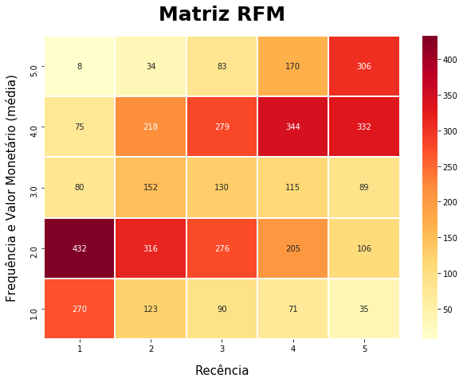

```python
plt.figure(figsize=(10,7))
plot = sns.heatmap(pivot_rfm,cmap='YlOrRd',linewidth=1, linecolor="white", annot=True, fmt ='.0f')
plot.set_xlabel('Recência', fontsize=15, labelpad=15)
plot.set_ylabel('Frequência e Valor Monetário (média)', fontsize=15, labelpad=15)
plot.set_title('Matriz RFM', fontsize=25, fontweight="bold", pad=20)
```

## Demais consultas

A matriz permite recuperar os clientes com qualquer filtro desejado, como por exemplo:

**Consultar clientes campeões (R nível 5 e média de F e M nível 5)**

```python
#Consultar segmento '555'
rfm[rfm['RFM_cluster']=='555']
```

|  | ClienteID | Recência | Frequência | ValorMonetario | R | F | M | RFM_cluster | RFM_score | FM_media |
| --- | --- | --- | --- | --- | --- | --- | --- | --- | --- | --- |
| 1 | 12347.0 | 2 | 182 | 4310.00 | 5 | 5 | 5 | 555 | 15.0 | 5.0 |
| 15 | 12362.0 | 3 | 266 | 5226.23 | 5 | 5 | 5 | 555 | 15.0 | 5.0 |
| 56 | 12417.0 | 3 | 192 | 3649.10 | 5 | 5 | 5 | 555 | 15.0 | 5.0 |
| 71 | 12433.0 | 1 | 420 | 13375.87 | 5 | 5 | 5 | 555 | 15.0 | 5.0 |
| 75 | 12437.0 | 2 | 200 | 4951.41 | 5 | 5 | 5 | 555 | 15.0 | 5.0 |
| ... | ... | ... | ... | ... | ... | ... | ... | ... | ... | ... |
| 4292 | 18223.0 | 5 | 272 | 6484.54 | 5 | 5 | 5 | 555 | 15.0 | 5.0 |
| 4294 | 18225.0 | 3 | 269 | 5504.96 | 5 | 5 | 5 | 555 | 15.0 | 5.0 |
| 4298 | 18229.0 | 12 | 164 | 7276.90 | 5 | 5 | 5 | 555 | 15.0 | 5.0 |
| 4310 | 18245.0 | 7 | 175 | 2567.06 | 5 | 5 | 5 | 555 | 15.0 | 5.0 |
| 4328 | 18272.0 | 3 | 166 | 3078.58 | 5 | 5 | 5 | 555 | 15.0 | 5.0 |

306 rows × 10 columns

## Atribuir classes

```python
rfm['R'] = rfm['R'].astype('int64')
rfm['FM_media'] = rfm['FM_media'].astype('int64')

def classificar(df):
    if (df['FM_media'] == 5) and (df['R'] == 1):
        return 'Não posso perdê-lo'
    elif (df['FM_media'] == 5) and ((df['R'] == 3) or (df['R'] == 4)):
        return 'Cliente leal'
    elif (df['FM_media'] == 5) and (df['R'] == 5):
        return 'Campeão'
    elif (df['FM_media'] == 4) and (df['R'] >= 3):
        return 'Cliente leal'
    elif (df['FM_media'] == 3) and (df['R'] == 3):
        return 'Precisa de atenção'
    elif ((df['FM_media'] == 3) or (df['FM_media'] == 2))  and (df['R'] > 3):
        return 'Lealdade potencial'
    elif ((df['FM_media'] == 2) or (df['FM_media'] == 1)) and (df['R'] == 1):
        return 'Perdido'
    elif (df['FM_media'] == 2) and (df['R'] == 2):
        return 'Hibernando'
    elif ((df['FM_media'] == 2) or (df['R'] == 1)) and (df['R'] == 3):
        return 'Prestes a hibernar'
    elif (df['FM_media'] == 1) and (df['R'] == 2):
        return 'Perdido'
    elif (df['FM_media'] == 1) and (df['R'] == 4):
        return 'Promissor'
    elif (df['FM_media'] == 1) and (df['R'] == 5):
        return 'Recentes'
    else:
        return 'Em risco'

rfm['Classe'] = rfm.apply(classificar,axis=1)
rfm
```

|  | ClienteID | Recência | Frequência | ValorMonetario | R | F | M | RFM_cluster | RFM_score | FM_media | Classe |
| --- | --- | --- | --- | --- | --- | --- | --- | --- | --- | --- | --- |
| 0 | 12346.0 | 326 | 1 | 77183.60 | 1 | 1 | 5 | 115 | 7.0 | 3 | Em risco |
| 1 | 12347.0 | 2 | 182 | 4310.00 | 5 | 5 | 5 | 555 | 15.0 | 5 | Campeão |
| 2 | 12348.0 | 75 | 31 | 1797.24 | 2 | 3 | 4 | 234 | 9.0 | 4 | Em risco |
| 3 | 12349.0 | 19 | 73 | 1757.55 | 4 | 4 | 4 | 444 | 12.0 | 4 | Cliente leal |
| 4 | 12350.0 | 310 | 17 | 334.40 | 1 | 2 | 2 | 122 | 5.0 | 2 | Perdido |
| ... | ... | ... | ... | ... | ... | ... | ... | ... | ... | ... | ... |
| 4334 | 18280.0 | 278 | 10 | 180.60 | 1 | 1 | 1 | 111 | 3.0 | 1 | Perdido |
| 4335 | 18281.0 | 181 | 7 | 80.82 | 1 | 1 | 1 | 111 | 3.0 | 1 | Perdido |
| 4336 | 18282.0 | 8 | 12 | 178.05 | 5 | 1 | 1 | 511 | 7.0 | 1 | Recentes |
| 4337 | 18283.0 | 4 | 721 | 2045.53 | 5 | 5 | 4 | 554 | 14.0 | 4 | Cliente leal |
| 4338 | 18287.0 | 43 | 70 | 1837.28 | 3 | 4 | 4 | 344 | 11.0 | 4 | Cliente leal |

4339 rows × 11 columns

Pronto, essa tabela por exeplo pode ser exportada para excel e encaminhada para outras estratégias direcionadas para cada cluster como e-mail marketing e CRM. o comando para exportar em excel é:

`rfm.to_excel("nomedaplanilha.xlsx", index=False)`

Isso cria uma planilha .xlsx na mesma pasta em que está o notebook. Caso queira especificar um local diferente para salvar é só escrever o endereço no disco:

`rfm.to_excel(C:endereco/nomedaplanilha.xlsx')`

**Referências**

[Conjunto de dados no repositório da UCI](https://archive.ics.uci.edu/ml/datasets/online+retail)

[Cohort Analysis & Customer Segmentation with RFM](https://www.kaggle.com/mahmoudelfahl/cohort-analysis-customer-segmentation-with-rfm)